# **Experiment Notebook**

## Setup Environment

```python
# DO NOT MODIFY THE CODE IN THIS CELL
!pip install -q utstd

from utstd.folders import *
from utstd.ipyrenders import *

at = AtFolder(
    course_code=36106,
    assignment="AT2",
)
at.run()

import warnings
warnings.simplefilter(action='ignore')
```

```
You can now save your data files in: c:\Users\brohao\Desktop\UTS\36106\ClassificationModels-36106-AT2\36106\assignment\AT2\data
```

## Student Information

```python
# <Student to fill this section and then remove this comment>
student_name = "Jiayu Hao"
student_id = "25948860"
```

```python
# DO NOT MODIFY THE CODE IN THIS CELL
print_tile(size="h1", key='student_name', value=student_name)
```

student_name

Jiayu Hao

```python
# DO NOT MODIFY THE CODE IN THIS CELL
print_tile(size="h1", key='student_id', value=student_id)
```

student_id

25948860

## 0. Python Packages

### 0.a Install Additional Packages

> If you are using additional packages, you need to install them here using the command: `! pip install <package_name>`

```python
!pip install numpy
!pip install matplotlib
!pip install seaborn
```

### 0.b Import Packages

```python
# DO NOT MODIFY THE CODE IN THIS CELL
import pandas as pd
import altair as alt
```

```python
import numpy as np
import matplotlib.pyplot as plt
import seaborn as sns
```

## A. Project Description

```python
# Explain clearly what is the goal of this project for the business. How will the results be used? What will be the impact of accurate or incorrect results?
business_objective = """
The goal of this project is to
classify existing retail credit customers into Good, Standard, and Poor risk bands
to support personalized offers, limit management, and early-warning actions.

The model’s predictions will be used to identify low-risk customers for cross-sell and
pre-approval opportunities, manage credit limits for standard-risk customers,
and prioritize outreach or collections for high-risk customers.

Accurate results will enable more efficient credit portfolio management,
improved customer targeting, and reduced default risk.

In contrast, incorrect predictions could lead to financial losses from misclassified
high-risk borrowers or reduced customer satisfaction and missed revenue opportunities
from overly conservative classifications.
"""
```

```python
# DO NOT MODIFY THE CODE IN THIS CELL
print_tile(size="h3", key='business_objective', value=business_objective)
```

business_objective

The goal of this project is to classify existing retail credit customers into Good, Standard, and Poor risk bands to support personalized offers, limit management, and early-warning actions. The model’s predictions will be used to identify low-risk customers for cross-sell and pre-approval opportunities, manage credit limits for standard-risk customers, and prioritize outreach or collections for high-risk customers. Accurate results will enable more efficient credit portfolio management, improved customer targeting, and reduced default risk. In contrast, incorrect predictions could lead to financial losses from misclassified high-risk borrowers or reduced customer satisfaction and missed revenue opportunities from overly conservative classifications.

## B. Dataset Understanding (Global Interpretation)

```python
# DO NOT MODIFY THE CODE IN THIS CELL
try:
  df = pd.read_csv(at.folder_path / "credit_rating.csv")
except Exception as e:
  print(e)
```

```python
print("Shape of dataset:", df.shape)   # rows * columns

# Overview of data types and non-null counts
print("\nDataset Info:")
print(df.info())

# First few rows
print("\nFirst 5 rows of testing set:")
pd.set_option("display.max_columns", None)
display(df.head())

# Summary statistics for numerical features
print("\nSummary statistics for numerical variables:")
display(df.describe().T)

# Summary for categorical features
print("\nUnique values count for categorical variables:")
categorical_cols = df.select_dtypes(include=["object", "category"]).columns
for col in categorical_cols:
    print(f"{col}: {df[col].nunique()} unique values")

# Missing values
print("\nMissing values per column:")
missing = df.isnull().sum()
missing = missing[missing > 0].sort_values(ascending=False)
display(missing)

# Duplicate rows
print("\nNumber of duplicate rows:", df.duplicated().sum())
```

```
Shape of dataset: (12500, 48)

Dataset Info:
<class 'pandas.core.frame.DataFrame'>
RangeIndex: 12500 entries, 0 to 12499
Data columns (total 48 columns):
 #   Column                      Non-Null Count  Dtype
---  ------                      --------------  -----
 0   customer_id                 12500 non-null  object
 1   prefix                      12500 non-null  object
 2   full_name                   12500 non-null  object
 3   gender                      12500 non-null  object
 4   dob                         12500 non-null  object
 5   age                         12500 non-null  int64
 6   birth_country               12500 non-null  object
```

[output cut: 46 more lines]

|  | customer_id | prefix | full_name | gender | dob | age | birth_country | email | phone_number | secondary_address | building_number | street_name | street_suffix | city | postcode | state_abbr | occupation | annual_income | count_bank_accounts | count_credit_cards | cc_number | cc_expiry | cc_security_code | cc_interest_rate | loans_count | avg_days_past_due | count_delayed_payment | credit_limit_change | count_credit_inquiries | … |
| --- | --- | --- | --- | --- | --- | --- | --- | --- | --- | --- | --- | --- | --- | --- | --- | --- | --- | --- | --- | --- | --- | --- | --- | --- | --- | --- | --- | --- | --- | --- |
| 0 | 5bd44cee-f2d0-457f-9b79-1fdd894da18c | Mr. | Kevin Moon | m | 1993-12-06 | 31 | AU | kimberlypark@example.org | (08)35431944 | Unit 93 | 0 | April Amble | Brow | Chaneyborough | 8442 | QLD | Journalist | 22229.060 | 6 | 4 | 2271879300837817 | 11/31 | 104 | 5.0 | 3 | 10 | 10 | 9.44 | 9 | … |
| 1 | 9cb378bd-57f0-4613-a987-b95bbdb84f8f | Dr. | Matthew May-Lewis | m | 1981-10-21 | 43 | NZ | garciathomas@example.net | 0485 357 742 | Level 2 | 43 | Davis Crest | Rest | Andrewborough | 2652 | TAS | Musician | 17060.705 | 8 | 3 | 349101291688485 | 09/30 | 661 | 11.0 | 4 | 24 | 8 | 9.64 | 2 | … |
| 2 | 0e0b24e2-74d7-48f1-9b45-e6cfbf79dbff | Dr. | Donald Sanchez | m | 2001-06-15 | 24 | AU | qlee@example.org | 20356212 | 937/ | 96 | Emily Little | Drive | New Chadbury | 2955 | NSW | Accountant | 34428.210 | 2 | 4 | 4634389038551183 | 08/30 | 977 | 8.0 | 0 | 3 | 12 | 8.51 | 0 | … |
| 3 | d45b3167-77e6-4b2a-96f3-a9bf2ee07621 | Mr. | Jonathan Thornton | m | 2004-01-23 | 21 | AU | cmorgan@example.com | 0627-6253 | Level 3 | 5 | William Pathway | Circle | Elliottside | 2381 | WA | Accountant | 12613.920 | 4 | 6 | 30359329057818 | 08/34 | 729 | 13.0 | 3 | 14 | 17 | 17.51 | 3 | … |
| 4 | 79a17520-248e-4bea-92b8-22c78d968172 | Mr. | Yasmin Agarwal | m | 1993-11-14 | 31 | IN | xtodd@example.com | 9957-3583 | 00/ | 5 | Martin Close | Part | Gonzalezberg | 3048 | TAS | Journalist | 34775.160 | 7 | 9 | 375257503725320 | 05/33 | 202 | 25.0 | 5 | 20 | 20 | 17.16 | 6 | … |

```
Summary statistics for numerical variables:
```

|  | count | mean | std | min | 25% | 50% | 75% | max |
| --- | --- | --- | --- | --- | --- | --- | --- | --- |
| age | 12500.0 | 3.330664e+01 | 1.076736e+01 | 1.400000e+01 | 2.400000e+01 | 3.300000e+01 | 4.200000e+01 | 5.600000e+01 |
| building_number | 12500.0 | 1.805667e+02 | 2.772560e+02 | 0.000000e+00 | 6.000000e+00 | 4.250000e+01 | 2.320000e+02 | 9.990000e+02 |
| postcode | 12500.0 | 3.168209e+03 | 1.811336e+03 | 2.000000e+02 | 2.602000e+03 | 2.694000e+03 | 2.968000e+03 | 9.996000e+03 |
| annual_income | 12500.0 | 5.050512e+04 | 3.830076e+04 | 7.005930e+03 | 1.934297e+04 | 3.699971e+04 | 7.168347e+04 | 1.799873e+05 |
| count_bank_accounts | 12500.0 | 5.368880e+00 | 2.594931e+00 | 0.000000e+00 | 3.000000e+00 | 5.000000e+00 | 7.000000e+00 | 1.100000e+01 |
| count_credit_cards | 12500.0 | 5.533760e+00 | 2.068024e+00 | 0.000000e+00 | 4.000000e+00 | 5.000000e+00 | 7.000000e+00 | 1.100000e+01 |
| cc_number | 12500.0 | 3.750285e+17 | 1.242247e+18 | 6.040204e+10 | 3.896755e+13 | 3.515906e+15 | 4.690149e+15 | 4.999833e+18 |
| cc_security_code | 12500.0 | 8.794893e+02 | 1.536073e+03 | 0.000000e+00 | 2.660000e+02 | 5.420000e+02 | 8.140000e+02 | 9.992000e+03 |
| cc_interest_rate | 12500.0 | 1.453208e+01 | 8.741636e+00 | 1.000000e+00 | 7.000000e+00 | 1.300000e+01 | 2.000000e+01 | 3.400000e+01 |
| loans_count | 12500.0 | 3.532880e+00 | 2.446442e+00 | 0.000000e+00 | 2.000000e+00 | 3.000000e+00 | 5.000000e+00 | 9.000000e+00 |
| avg_days_past_due | 12500.0 | 2.106504e+01 | 1.486938e+01 | -5.000000e+00 | 1.000000e+01 | 1.800000e+01 | 2.800000e+01 | 6.700000e+01 |
| count_delayed_payment | 12500.0 | 1.334144e+01 | 6.271485e+00 | 0.000000e+00 | 9.000000e+00 | 1.400000e+01 | 1.800000e+01 | 2.800000e+01 |
| credit_limit_change | 12500.0 | 1.039298e+01 | 6.771164e+00 | -6.310000e+00 | 5.340000e+00 | 9.380000e+00 | 1.485000e+01 | 3.697000e+01 |
| count_credit_inquiries | 12500.0 | 5.759440e+00 | 3.828987e+00 | 0.000000e+00 | 3.000000e+00 | 5.000000e+00 | 8.000000e+00 | 1.700000e+01 |
| outstanding_debt | 12500.0 | 1.426220e+03 | 1.155169e+03 | 2.300000e-01 | 5.660725e+02 | 1.166155e+03 | 1.945963e+03 | 4.998070e+03 |
| credit_ratio | 12500.0 | 3.228900e+01 | 5.119387e+00 | 2.088008e+01 | 2.801095e+01 | 3.235725e+01 | 3.650483e+01 | 4.817660e+01 |
| count_credit_history_years | 12500.0 | 2.211582e+02 | 9.970293e+01 | 2.000000e+00 | 1.447500e+02 | 2.190000e+02 | 3.020000e+02 | 4.040000e+02 |
| monthly_emi_payment | 12500.0 | 8.818938e+01 | 8.326490e+01 | -1.000000e+00 | 2.556320e+01 | 6.150646e+01 | 1.313871e+02 | 3.574061e+02 |
| _monthly_invested_amount | 12500.0 | 1.941276e+02 | 1.953396e+02 | 0.000000e+00 | 7.386528e+01 | 1.289431e+02 | 2.333648e+02 | 1.885645e+03 |
| monthly_balance | 12500.0 | 4.036475e+02 | 2.150077e+02 | 4.191236e-01 | 2.697617e+02 | 3.375976e+02 | 4.699648e+02 | 1.528886e+03 |

```
Unique values count for categorical variables:
customer_id: 12500 unique values
prefix: 5 unique values
full_name: 11614 unique values
gender: 2 unique values
dob: 8380 unique values
birth_country: 13 unique values
email: 12169 unique values
phone_number: 12500 unique values
secondary_address: 2659 unique values
street_name: 11712 unique values
street_suffix: 200 unique values
city: 9369 unique values
state_abbr: 8 unique values
occupation: 15 unique values
cc_expiry: 121 unique values
credit_mix: 3 unique values
min_amount_payment: 2 unique values
payment_behaviour: 6 unique values
last_9_loan_type: 10 unique values
last_8_loan_type: 10 unique values
last_7_loan_type: 10 unique values
last_6_loan_type: 10 unique values
last_5_loan_type: 10 unique values
last_4_loan_type: 10 unique values
last_3_loan_type: 10 unique values
last_2_loan_type: 10 unique values
last_1_loan_type: 10 unique values
credit_rating: 3 unique values

Missing values per column:
```

```
Series([], dtype: int64)
```

```
Number of duplicate rows: 0
```

```python
# Student Note: personal thinking
data_set_insights = """
The dataset has 12,500 rows and 48 columns.
There are no missing or duplicate rows, but some columns contain placeholder or pseudo-missing values.
It includes both numerical and categorical features, and many columns contain
PII (personally identifiable information) such as names, emails, phone numbers,
and addresses, which raise privacy concerns.

Privacy issues:

Clear PII or location-related columns not needed for modeling: customer_id, prefix,
full_name, email, phone_number, secondary_address, building_number, street_name,
street_suffix, city, postcode, state_abbr, dob.
→ These should be removed or anonymized for privacy compliance.

Extremely high privacy or data leakage risk: cc_number, cc_security_code, cc_expiry
— no business value, high ethical and security risk.

cc_interest_rate is likely determined by credit rating (reverse causality)
→ exclude from main model, maybe use in sensitivity tests.

credit_limit_change depends on prior credit decisions
→ exclude or test separately.

credit_mix overlaps with the target variable (Good / Standard / Poor)
→ exclude in main model; may include in comparison experiments with ethical disclosure.

Time-related redundancy: dob and age are duplicates
→ keep age, drop dob; cc_expiry also contains sensitive and time-based effects, best removed.

Numerical issues:

Outliers and invalid values:

avg_days_past_due has a minimum of –5 → likely data error;
set to 0 or make a “paid early” binary feature.

monthly_emi_payment has a minimum of –1 → invalid; set to 0 or mark as missing.

Unit correction:

count_credit_history_years mean ≈ 221, max 404 → likely measured in months;
create credit_history_years = count_credit_history_years / 12.

credit_ratio ranges 20.9–48.2 → appears to be a percentage;
treat as % in plots but divide by 100 for model input.

Skewed variables: annual_income, outstanding_debt, monthly_invested_amount, monthly_balance
are right-skewed; apply log1p, Winsorization, or RobustScaler to stabilize the model.

Categorical issues:

High-cardinality features (full_name, email, street_name, city): no business meaning
and high privacy risk → exclude.

Fields with placeholder or “unknown” categories (e.g., No Loan, Not Specified) should:

Keep a dedicated “Unknown/None” category and record its frequency.

For recent loan types (last_1_loan_type … last_9_loan_type), avoid direct one-hot encoding;
instead, engineer lower-dimensional features:

Most recent loan type (last_1_loan_type).

Binary flag for recent high-risk loan types (e.g., Payday).

Counts or proportions of each type.

Diversity measure (entropy) of loan types.
"""
```

## C. Feature Understanding (Local Interpretation)

### C.1 Explore Target Variable

> Save the name of column used as the target variable and call it `target_name`

> You can add more cells in this section

```python
target_name = 'credit_rating'
```

```python
# Sharper plots
plt.rcParams["figure.dpi"] = 120
```

```
credit_rating
Standard    6618
Poor        3646
Good        2236
Name: count, dtype: int64
credit_rating
Standard    0.52944
Poor        0.29168
Good        0.17888
Name: proportion, dtype: float64
```

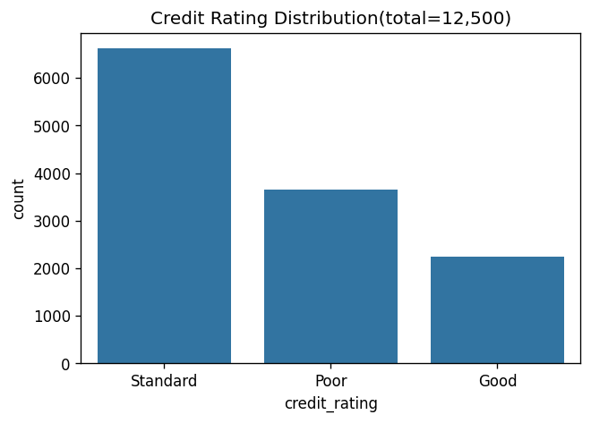

```python
print(df[target_name].value_counts())
print(df[target_name].value_counts(normalize=True))

plt.figure(figsize=(6,4))
sns.countplot(x=target_name, data=df, order=df[target_name].value_counts().index)
plt.title("Credit Rating Distribution(total=12,500)")
plt.show()
```

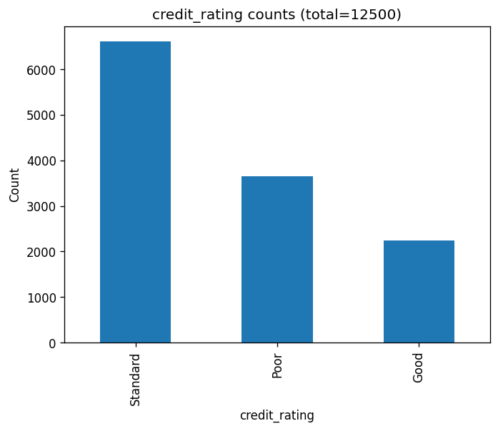

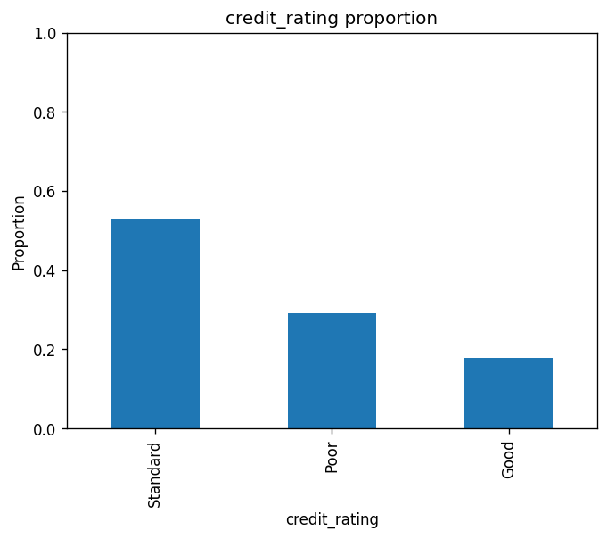

```python
# Target counts
plt.figure()
df[target_name].value_counts().plot(kind="bar")
plt.title(f"{target_name} counts (total={len(df)})")
plt.ylabel("Count")
plt.xlabel(target_name)
plt.show()


# Target Proportion
plt.figure()
(df[target_name].value_counts(normalize=True)).plot(kind="bar")
plt.title(f"{target_name} proportion")
plt.ylabel("Proportion")
plt.ylim(0,1)
plt.show()
```

```python
# provide a detailed analysis on the target variable, its distribution, limitations, issues, ...
target_insights = """
The goal of this project is to classify bank customers into Good, Standard, or Poor credit
rating groups to support credit decisions, personalized offers, and early risk alerts.
The results will be used to identify low-risk customers for promotions,
monitor standard customers for limit management, and detect poor customers
for early collection actions.

Accurate predictions will help reduce losses, improve targeting, and support fair,
data-driven lending decisions.
Incorrect predictions could expose the bank to credit risk if poor customers are
misclassified as good, or lead to missed business opportunities and lower satisfaction
if good customers are treated as risky.
"""
```

```python
# DO NOT MODIFY THE CODE IN THIS CELL
print_tile(size="h3", key='target_insights', value=target_insights)
```

target_insights

The goal of this project is to classify bank customers into Good, Standard, or Poor credit rating groups to support credit decisions, personalized offers, and early risk alerts. The results will be used to identify low-risk customers for promotions, monitor standard customers for limit management, and detect poor customers for early collection actions. Accurate predictions will help reduce losses, improve targeting, and support fair, data-driven lending decisions. Incorrect predictions could expose the bank to credit risk if poor customers are misclassified as good, or lead to missed business opportunities and lower satisfaction if good customers are treated as risky.

### C.2 Explore Feature of Interest `avg_days_past_due`

> You can add more cells in this section

```python
feat = "avg_days_past_due"
```

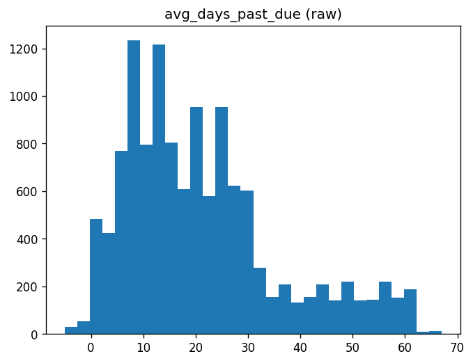

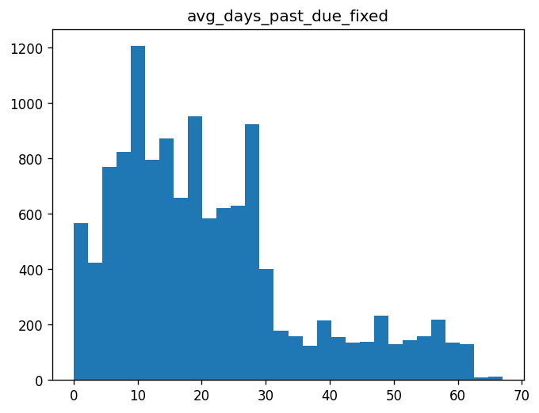

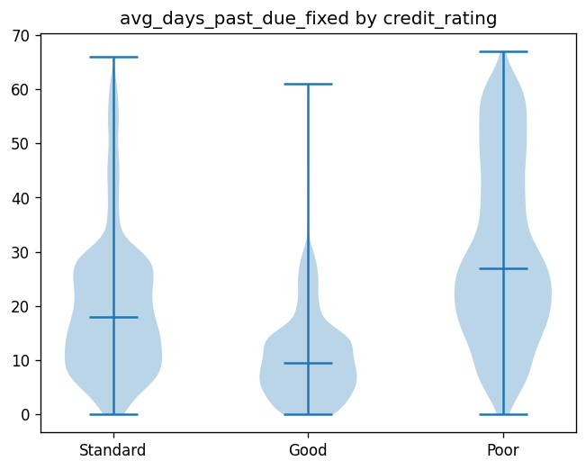

```python
# Cleaning: negatives -> 0
df = df.copy()
df["avg_days_past_due_fixed"] = df["avg_days_past_due"].clip(lower=0)  # negatives -> 0


# Overall hist (raw & fixed)
plt.figure()
plt.hist(df["avg_days_past_due"].dropna(), bins=30)
plt.title("avg_days_past_due (raw)")
plt.show()

plt.figure()
plt.hist(df["avg_days_past_due_fixed"].dropna(), bins=30)
plt.title("avg_days_past_due_fixed")
plt.show()

# Grouped violin
groups = [df.loc[df["credit_rating"]==c, "avg_days_past_due_fixed"].dropna().values for c in df["credit_rating"].unique()]
plt.figure()
plt.violinplot(groups, showmedians=True)
plt.xticks(range(1,len(groups)+1), df["credit_rating"].unique())
plt.title("avg_days_past_due_fixed"+" by credit_rating")
plt.show()
```

```python
# provide a detailed analysis on the selected feature, its distribution, limitations, issues, ...
feature_1_insights = """
The feature avg_days_past_due measures the average number of days a customer delays payment.
Before cleaning, some values were negative, which is not possible. These were corrected to zero.
Most values are between 0 and 30 days, with a few cases above 60 days.
The distribution is right-skewed, showing that most customers pay on time or with short delays.
After fixing negatives, the shape stays similar but more realistic.

By credit rating, Poor customers have much higher median and wider spread,
while Good customers usually have very small delays.

This feature is a strong indicator of repayment behavior.
Limitations include possible data entry errors and missing context about loan type or payment size.
It should be scaled or capped to reduce the effect of extreme delays.
"""
```

```python
# DO NOT MODIFY THE CODE IN THIS CELL
print_tile(size="h3", key='feature_1_insights', value=feature_1_insights)
```

feature_1_insights

The feature avg_days_past_due measures the average number of days a customer delays payment. Before cleaning, some values were negative, which is not possible. These were corrected to zero. Most values are between 0 and 30 days, with a few cases above 60 days. The distribution is right-skewed, showing that most customers pay on time or with short delays. After fixing negatives, the shape stays similar but more realistic. By credit rating, Poor customers have much higher median and wider spread, while Good customers usually have very small delays. This feature is a strong indicator of repayment behavior. Limitations include possible data entry errors and missing context about loan type or payment size. It should be scaled or capped to reduce the effect of extreme delays.

### C.3 Explore Feature of Interest `count_delayed_payment`

> You can add more cells in this section

```python
feat = "count_delayed_payment"
```

```python
df["late_rate"] = df[feat] / np.maximum(df["loans_count"], 1)
```

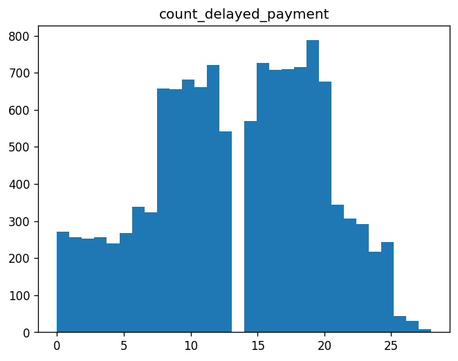

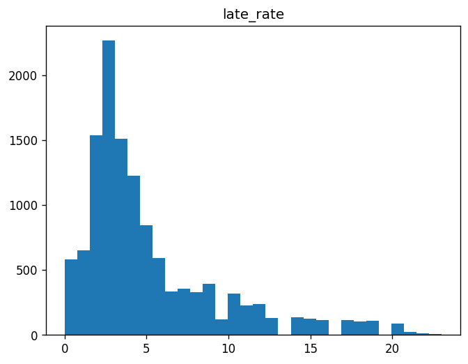

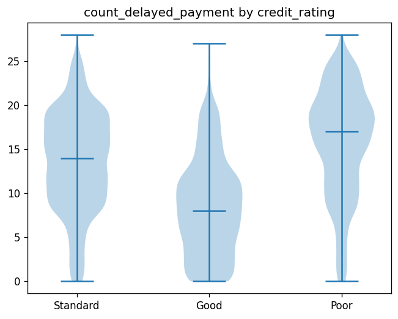

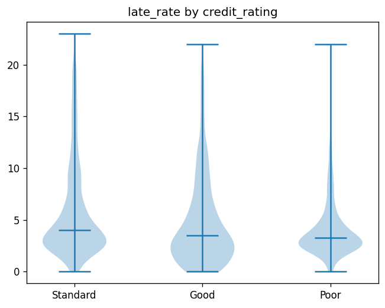

```python
# Distribution
# of feat
plt.figure()
plt.hist(df[feat].dropna(), bins=30)
plt.title(feat)
plt.show()
# of rate(extension)
plt.figure()
plt.hist(df["late_rate"].dropna(), bins=30)
plt.title("late_rate")
plt.show()

# Violin
groups = [df.loc[df["credit_rating"]==c, feat].dropna().values for c in df["credit_rating"].unique()]
plt.figure()
plt.violinplot(groups, showmedians=True)
plt.xticks(range(1,len(groups)+1), df["credit_rating"].unique())
plt.title(feat+" by credit_rating")
plt.show()

# Violin
groups = [df.loc[df["credit_rating"]==c, "late_rate"].dropna().values for c in df["credit_rating"].unique()]
plt.figure()
plt.violinplot(groups, showmedians=True)
plt.xticks(range(1,len(groups)+1), df["credit_rating"].unique())
plt.title("late_rate"+" by credit_rating")
plt.show()
```

```python
# provide a detailed analysis on the selected feature, its distribution, limitations, issues, ...
feature_2_insights = """
The feature count_delayed_payment shows how many times a customer made late payments.
Most values are between 5 and 20, with a few near 0 or above 25. The distribution has
several peaks, suggesting grouped or rounded data.

When adjusted by the number of loans (late_rate), most customers have a small delay rate below 5.
Poor customers have higher delay counts and wider spread, while Good customers delay less often.
This feature is a clear indicator of repayment reliability.

However, it may depend on loan history length—customers with more loans can have more delays
even with good habits.

It is useful but should be normalized or combined with loan count to avoid bias.

It seems that late_rate is better than count_delayed_payment, but result is the opposite.
"""
```

```python
# DO NOT MODIFY THE CODE IN THIS CELL
print_tile(size="h3", key='feature_2_insights', value=feature_2_insights)
```

feature_2_insights

The feature count_delayed_payment shows how many times a customer made late payments. Most values are between 5 and 20, with a few near 0 or above 25. The distribution has several peaks, suggesting grouped or rounded data. When adjusted by the number of loans (late_rate), most customers have a small delay rate below 5. Poor customers have higher delay counts and wider spread, while Good customers delay less often. This feature is a clear indicator of repayment reliability. However, it may depend on loan history length—customers with more loans can have more delays even with good habits. It is useful but should be normalized or combined with loan count to avoid bias. It seems that late_rate is better than count_delayed_payment, but result is the opposite.

### C.4 Explore Feature of Interest `count_credit_inquiries`

> You can add more cells in this section

```python
# <Student to fill this section and then remove this comment>
feat = "count_credit_inquiries"
```

```python
df["inq_ge_8"] = (df[feat] >= 8).astype(int)
```

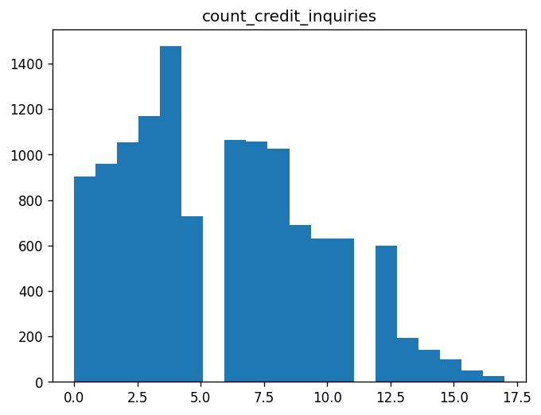

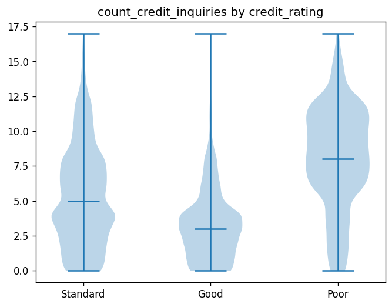

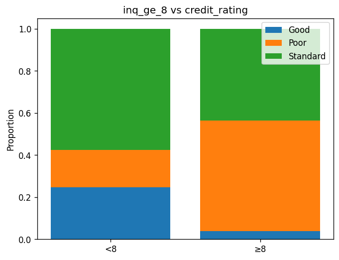

```python
# Distribution
plt.figure(); plt.hist(df[feat].dropna(), bins=20); plt.title(feat); plt.show()
# Violin
groups = [df.loc[df["credit_rating"]==c, feat].dropna().values for c in df["credit_rating"].unique()]
plt.figure(); plt.violinplot(groups, showmedians=True); plt.xticks(range(1,len(groups)+1), df["credit_rating"].unique()); plt.title(feat+" by credit_rating"); plt.show()

# High-threshold flag
ct = pd.crosstab(df["inq_ge_8"].map({0:"<8",1:"≥8"}), df["credit_rating"], normalize="index")
plt.figure(); bottom = np.zeros(len(ct))
for cls in ct.columns: plt.bar(range(len(ct)), ct[cls].values, bottom=bottom, label=cls); bottom += ct[cls].values
plt.xticks(range(len(ct)), ct.index); plt.ylabel("Proportion"); plt.title("inq_ge_8 vs credit_rating"); plt.legend(); plt.show()
```

```python
# provide a detailed analysis on the selected feature, its distribution, limitations, issues, ...

feature_3_insights = """
Most people have 0–8 inquiries, with a few above 12.
Good customers usually have fewer than 5.
Standard customers are in the middle.
Poor customers often have 8 or more.
This feature may be affected by short-term events, not always show long-term habits.
Still, it is a strong signal for credit risk.
"""
```

```python
# DO NOT MODIFY THE CODE IN THIS CELL
print_tile(size="h3", key='feature_3_insights', value=feature_3_insights)
```

feature_3_insights

Most people have 0–8 inquiries, with a few above 12. Good customers usually have fewer than 5. Standard customers are in the middle. Poor customers often have 8 or more. This feature may be affected by short-term events, not always show long-term habits. Still, it is a strong signal for credit risk.